# Exploration of The Texas Power Grid and Wind Power in Light of Recent Grid Failure

## DAT 301 Project 2

### Background

The purpose of my project is to examine the Texas energy grid. Texas is almost completely separate from the rest of the United States in terms of power generation, and its grid managed by the Electric Reliability Council of Texas (ERCOT).In February of 2021, the grid experience its largest failure yet, leading to hunderds of deaths. There is a lot of speculation for why this is happening. From spikes in energy use during the winter months, to lower regulations allowing for relaxed maintenance, to large scale cryptocurrency mining caused by the state's historically low energy costs, to wind power drops, there are numerous factors contributing to these failures. In this analysis, we will look at generator data across different types of fuel, the state's annual power consumption, and review Texas governor Greg Abbott's accusations purporting that renewable energy sources such as wind played a significant role in the outages. We will ask if wind is really the key contributor, as well as discuss what needs to change to prevent these events in the future.

```python
#Import needed Libraries
import matplotlib as mp
import matplotlib.pyplot as plt
import numpy as np
import pandas as pd
import geopandas as gpd


#Generator Stats
kMvar = pd.read_csv('Texas7k_CostCurves_Nov2021.csv')

#Generator Locations and operators (all of USA)
plants = gpd.read_file('Power_Plants.shp')


#Input US shapefile and cut down to just Texas
usa = gpd.read_file('cb_2018_us_state_500k.shp')
texas = usa[usa.STATEFP == '48']



#Grid Usage by Hour for 2021
use = pd.read_csv('Native_Load_2021.csv')
use.ERCOT = use.ERCOT.replace(',','', regex = True)
use.ERCOT = use.ERCOT.astype(float)

#Wind Production by Hour for 2021
wind = pd.read_csv('ERCOT_2021_Hourly_WindSolar_Output.csv')
wind = wind[wind["ERCOT.LOAD"].notnull()]

#Albers Conversion
texas = texas.to_crs(5070)
plants = plants.to_crs(5070)


# Filter to plants from Texas, with known generation types that produce power
plants = plants[plants.STATE == 'TX']
plants = plants[plants.TYPE != 'NOT AVAILABLE']
plants = plants[plants.NAICS_DESC != 'NOT AVAILABLE']
plants = plants[plants.OPERATOR != 'NOT AVAILABLE']
plants = plants[plants.OPER_CAP >= 0]



#Prep for Merge, one has string coulum, the other has int
plants["PLANT_CODE"] = plants["PLANT_CODE"].astype(int)

#Merge Data Frames
all_plants = plants.merge(kMvar, how = "left", left_on = 'PLANT_CODE', right_on = 'EIA-860 Plant Code')
all_plants2 = all_plants.iloc[:,[1,2,3,4,8,9,10,14,15,16,17,23,25,26,27,35,36,37,42, 43, 44, 48]]
all_plants2 = all_plants2[all_plants.GenMWMax.notnull()]



#Months List
months = ['January', 'February',
          'March', 'April',
          'May', 'June',
          'July', 'August',
          'September', 'October',
          'November', 'December']
#Days List
days = list(range(0,28))

#Stats Caluclations
#Maximum MW that can be generated by the system as a whole
Tot_Possible_MW = all_plants2.GenMWMax.sum()

#Maximum MW load the system experienced in 2021
max_usage = use.ERCOT.max()
```

### The Data

There are four main data sets used in this project (not including the shape file used for mapping). The first includes geospacial locations and other basic information on generators across the United States. The second contains basic data on the ERCOT generators, including their megawatt output (MW). The third is ERCOT's energy demand report by hour for the year of 2021. The final dataset contains ERCOT's wind power production by hour for the year of 2021. These four data sets allow us to look at the general layout of the texas power grid, as well as perform some analysis on the significance of wind power in the grid.

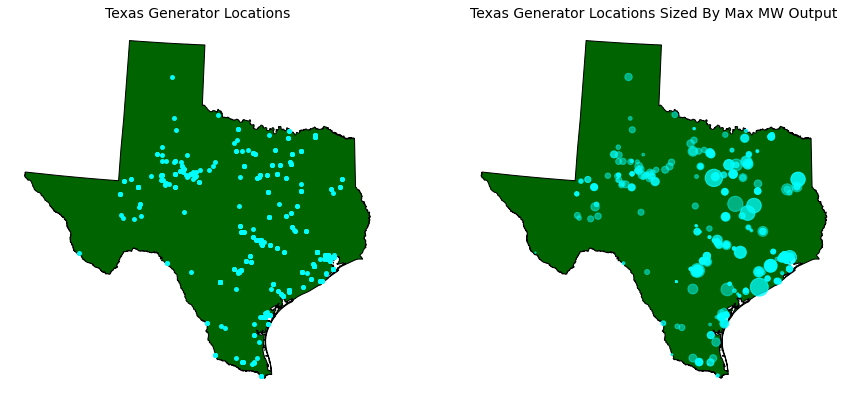

```python
#base plot
fig, ax = plt.subplots(1,2, figsize = (15,15))

texas.plot(ax = ax[0],
           edgecolor = 'black',
           color = 'darkgreen')
all_plants2.plot(ax = ax[0],
                 markersize = 15,
                 color = 'aqua')
ax[0].set_axis_off()
ax[0].set_title("Texas Generator Locations", fontsize = 14);
#generator locations

texas.plot(ax = ax[1],
           edgecolor = 'black',
           color = 'darkgreen')
all_plants2.plot(ax = ax[1],
                 markersize = all_plants2["GenMWMax"] / 4,
                 alpha = 0.5,
                 color = "aqua")
ax[1].set_axis_off()
ax[1].set_title("Texas Generator Locations Sized By Max MW Output", fontsize = 14);
#generator locations sized by their output
```

#### Generator Locations

If we take a look at the locations of the generators on the ercot grid, we can see that the bulk of production comes from the eastern half of the state.

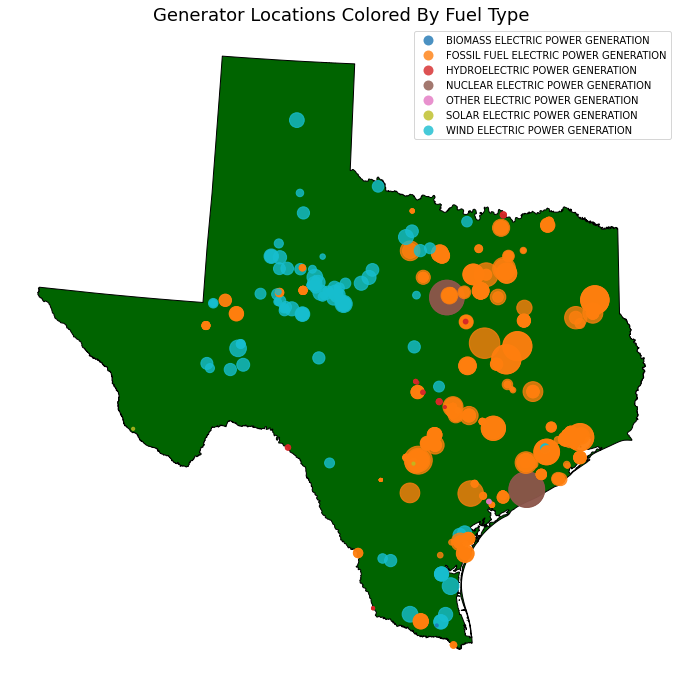

```python
fig, ax = plt.subplots(1,1, figsize = (12,12))

texas.plot(ax = ax, edgecolor = 'black', color = 'darkgreen')
b = all_plants2.plot(ax = ax,
                     column = all_plants2.NAICS_DESC,
                     markersize = all_plants2.GenMWMax,
                     alpha = 0.8,
                     legend = True)


b.set_axis_off()
ax.set_title('Generator Locations Colored By Fuel Type', fontsize = 18);


#Darker Colors = More Generators
```

### Different Kinds of Energy

There are 6 fuel types that make up most of the energy production in Texas. These include Biomass, Fossil Fuel, Hydroelectric, Nuclear, Solar, and Wind generators. We can draw some natural conclusions just from the data on the map. Most wind production seems to be concentrated to the North West region while most Fossil Fuel production is located in the Eastern half. We can also see that Solar, Nuclear, and Biomass operations appear to be few and far between. We can also see that Nuclear and Fossil Fuel generators seem to generally produce the most power on an individual basis, whereas Hydroelectric generators produce on a smaller scale.

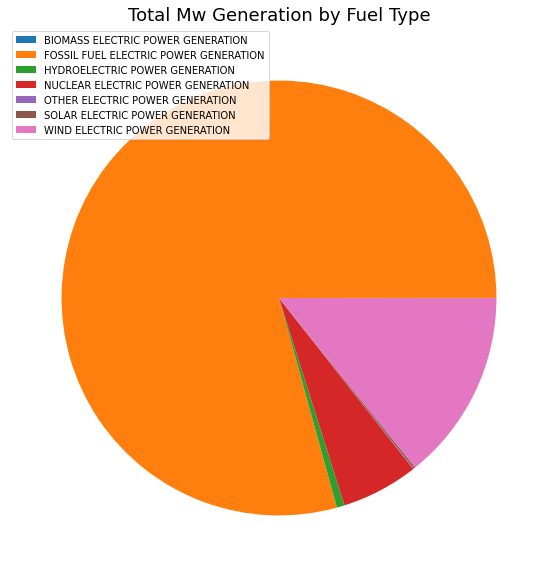

```python
plant_type_MW = all_plants2.groupby(by = all_plants2.NAICS_DESC).sum().GenMWMax
plant_type_MW


fig, ax = plt.subplots(1,1, figsize = (10,10))
plant_type_MW.plot.pie(ax = ax,
                       legend = True,
                       labels = ['','','','','','',''],
                       ylabel = '')

ax.legend(labels = plant_type_MW.index, loc = 'upper left')
ax.set_title("Total Mw Generation by Fuel Type", fontsize = 18);
```

### Enery Types and Their Production Caps

For this analysis, the chart percentage is based on total max energy production for each fuel type. As can be expected, fossil fuels account for the bulk of energy production, with wind coming in at a distant second, and nuclear at third. We can see based on this model that the bulk of the grid relies on fossil fuels, i.e. non-renewable resources, making other sources almost trivial in terms of power production. This is to be expected as fossil fuel energy production makes up for 63.3 percent of electricity production globally. With Texas having 79.3 percent of their electricity come from fossil fuels, their reliance on non renewable energy sources is above average.

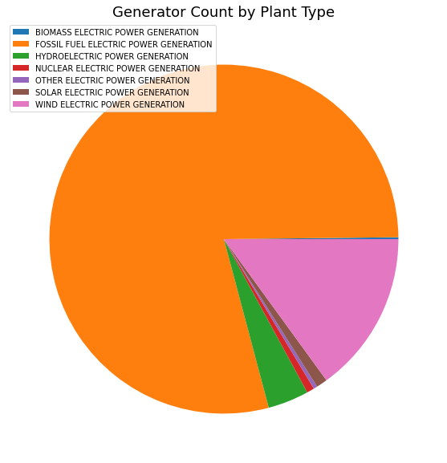

```python
plant_type_MW = all_plants2.groupby(by = all_plants2.NAICS_DESC).count().GenMWMax
plant_type_MW


fig, ax = plt.subplots(1,1, figsize = (10,10))
plant_type_MW.plot.pie(ax = ax,
                       legend = True,
                       labels = ['','','','','','',''],
                       ylabel = '')

ax.legend(labels = plant_type_MW.index, loc = 'upper left')
ax.set_title("Generator Count by Plant Type", fontsize = 18);
```

### So What Are These Outages?

ERCOT’s operations change based on the amount of reserve power the grid produces. The non-emergency operations reserve cutoff is at 3000 MW of reserve power on the grid. After this there are three emergency reserve levels and a warning level, which are met with certain countermeasures to prevent total uncontrolled grid failure. The levels are as follows.

#### Warning Level (below 3000 MW in reserve)

- Run all available generators
- Pull power from small customers who are paid to stop usage in these situations
- Have transmission companies reduce grid voltage.

#### Level 1 (below 2300 MW in reserve)

- Borrow power from neighbor grids

#### Level 2 (below 1750 MW in reserve)

- Ask the public to conserve energy
- Pull power from large customers who are paid to stop usage in these situations

#### Level 3 (below 1375 MW in reserve)

- Controlled Outages (rolling blackouts)

#### Total Failure (below 1000 MW in reserve)

- Grid frequency no longer maintainable at 60 Hz

In February of 2021, the largest controlled outage in ERCOT history occurred. Previously the highest reduction of power had been 4000 MW in 2011. The 2021 outages saw a 20000 MW reduction, 5 times that of any other in history. This lead to the deaths of an estmated 246-702 people. The underlying reason for the outages was an influx in winter storms, with three large storms over the course of a ten day period causing an unexpected spike in energy demand.

[figure not shown]

```python
fig, ax = plt.subplots(1,1, figsize = (12,12))


useNoon = use[use['Hour Ending'].str.contains('12:00')]
useMorn = use[use['Hour Ending'].str.contains('16:00')]
useEven = use[use['Hour Ending'].str.contains('18:00')]


useMorn.ERCOT.plot.line(ax = ax,
                   xlim = (0,8760),
                       color = 'green')

useNoon.ERCOT.plot.line(ax = ax,
                   xlim = (0,8760),
                       color = 'red')

useEven.ERCOT.plot.line(ax = ax,
                   xlim = (0,8760),
                       color = 'blue')

ax.legend(['6:00 AM', '12:00 PM', '6:00 PM'])
ax.set_xticks(range(0,8760, 730));
ax.set_xticklabels(months);
ax.set_title("System Load By Time of Day 2021", fontsize = 18);
```

### Demand Across 2021

[figure not shown]

```python
fig, ax = plt.subplots(1,1, figsize = (12,12))


wind["ERCOT.WIND.GEN"].plot.line(ax = ax,
                   xlim = (0,8760),
                       color = 'black')

wind["ERCOT.LOAD"].plot.line(ax = ax,
                   xlim = (0,8760),
                       color = 'green')


wind["ERCOT.LOAD"].rolling(100).mean().plot.line(ax = ax,
                   xlim = (730,1460),
                       color = 'red')


ax.legend(['Wind Generation MW', 'System Load MW', 'Average Load'])
ax.set_xticks(range(0,8760, 730));
ax.set_xticklabels(months);
ax.set_title("System Load and Wind Generation 2021", fontsize = 18);
```

### The Role of Wind

Above we have a graph of total demand vs wind energy supply for 2021. as can be seen, wind power does not account for the bulk of power generated. It does however tend to fluctuate highly, with a maximum output of around 20000 MW in 2021, and often fluctuating between this and near zero production year round.

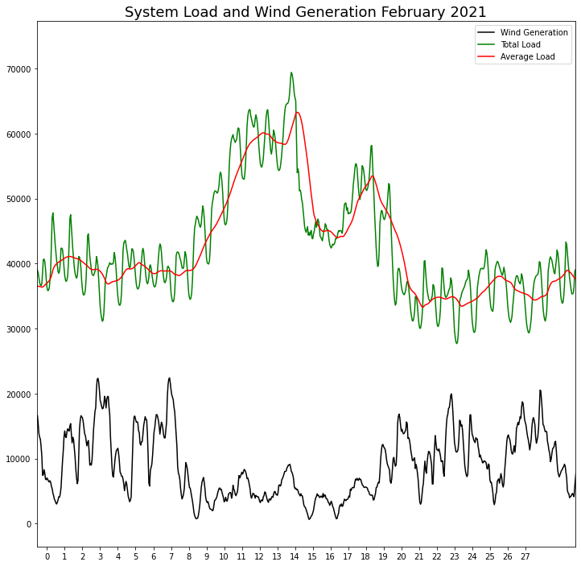

```python
fig, ax = plt.subplots(1,1, figsize = (12,12))


wind["ERCOT.WIND.GEN"].plot.line(ax = ax,
                   xlim = (730,1460),
                       color = 'black')

wind["ERCOT.LOAD"].plot.line(ax = ax,
                   xlim = (730,1460),
                       color = 'green')

wind["ERCOT.LOAD"].rolling(24).mean().plot.line(ax = ax,
                   xlim = (730,1460),
                       color = 'red')




ax.legend(['Wind Generation', 'Total Load', 'Average Load'])
ax.set_xticks(range(744,1406,24));
ax.set_xticklabels(days);
ax.set_title("System Load and Wind Generation February 2021", fontsize = 18);
```

### A Closer Look

The above graph shows the same data as before, but concentrated on the month of February. We can see that there is definitly a dip in wind energy production around the same time as the demand spike, which could provide evidence for why wind production was blamed for the issues.

### Conclusion

Looking at the data, we can see the texas power grid is made up of many sizes and types of generators. In light of the winter blackouts of 2021, we can see there was definitley a drop in wind production, with peak production during the outages falling by around 10000 MW. However, as stated earlier, ERCOT reports that the blackouts cut around 20000 MW of power, meaning that at most, "windmills freezing" or various other wind power issues could only account for about half of shortage. This doesn't take into account that the surplus is ideally kept above 3000 MW when not in a state of emergency. This leaves us about 13000 MW short of the demand at the time. As ERCOT would later report, this was mostly due to failure to winterize fossil fuel generators, which leads us back to the origional question. What needs to change? In short, there needs to be more regulation on the maintenance and upkeeep of the grid. Although the current system has resulted in very low energy cost in comparasin to the rest of the US, lives are put at stake when we sacrifice safety for profit.

### Sources:

Outage Prevention System Info- https://www.ercot.com/files/docs/2022/02/02/2022_EEA_Overview.pdf

System Load History Data- https://www.ercot.com/gridinfo/load/load_hist

Generator Location Data- https://hifld-geoplatform.opendata.arcgis.com/datasets/geoplatform::power-plants-1/about

Wind Generator Output Data- https://www.ercot.com/gridinfo/generation

Generator Output and Specification Data- https://electricgrids.engr.tamu.edu/electric-grid-test-cases/datasets-for-arpa-e-perform-program/

Geographic Map of Texas- https://www.census.gov/geographies/mapping-files/time-series/geo/carto-boundary-file.html